# Exercise 4: Cluster Analysis

**Course Instructor**: Dr. Suborna Ahmed

**Submission**: Brandon Weigland and Sandra Inusah

1. Write your code and answers in this RMD file
2. Knit your completed RMD file to WORD document
3. Check and upload your WORD document to Exercise 4 on Canvas

## Exercise Objectives

1. To become familiar with Cluster Analysis as a tool to uncover “natural” groups in data.
2. To learn how to obtain clustering solutions for alternative methods (and distance metrics) and choose one of the results.

## General Description

In Exercise 4, you will again use the data gathered by Tracy Hooper on bird abundances, along with vegetation and other variables in a grassland area (a subset of her data is used in FRST 531 with her approval). The data have been provided as TRABREV3.txt. Using cluster analysis, you will cluster the sites based on bird compositions. NOTE: The variable names are standard 4-letter bird species codes that you can find on the web if you wish.

The overall objective is to final “natural” clusters in the bird data. For this, you will use a few alternative hierarchical methods, and then the k-means non-hierarchical method. From the results, you will choose one of the clustering solutions that best segregates the sites by bird composition.

## Process

1. For this analysis, the data have been provided as *TRABREV3.txt* along with R code as *Exercise 4: Cluster Analysis - Student File. Rmd*.
2. Specifically, there are four sections in this exercise:
- In Part 1 (Data preparation), you will need to run the R code so as to read and clean the original data in preparation for your cluster analyses.
- In Part 2 (Hierarchical clustering of sites by bird composition), you will examine four hierarchical clustering alternatives (hc1 to hc3 provided in the R code, plus you will add code for hc4) and answer Questions 1 to 4 to guide you through the outputs and interpret the results.
- In Part 3 (Non-Hierarchical clustering of sites by bird composition), you will perform analysis using k-means clustering altering the number of clusters from one to six, with a graph showing the within sums of squares. You will need to run the R code and get/understand/interpret the outputs from running the code. You will be answering Questions 5 to 7 to compare different methods and make your choice.
- The last part contains extra R code where the data are transposed. In Parts 1 to 3, the question is: Which sites have a similar bird composition? Now, the transpose of the data is done, and the goal is to cluster the birds using the sites. The question becomes: Which bird species occur on the same sites? This part is just for fun, and shows how the clustering can be altered to group variables instead of observations to match the question posed.

**NOTE**: Under each question in the Rmd file, you will see dedicated code chunks or blank spaces that are prepared for you to write your own code and add your answers. As you answer the questions, paste in the relevant R outputs to support your answers.

## Part 1: Data Preparation

Data from an outside text file from a birds in grasslands study by Tracy Hooper (subset of her data used by permission) is brought in to R from an outside space-delimited text file. Alternatively, you could bring the text file into EXCEL and save it as a .csv file. Using only information on bird species, the goal is to cluster the sites using the bird species.

### Read the data

Let’s first load it to R as “studydat”.

```r
# Make sure you put this RMD file and TRABREV3.txt in the same folder before running the code
studydat<- read.table("TRABREV3.txt", header=T)

#studydat<-read.csv("TRABREV3 (1).txt", header=T) # this line of code can read the comma delimited file instead.
```

Let’s print out some aspects of the data to just check it out.

```r
class(studydat)  # what type of object is it?
names(studydat)  # print out the column (i.e., variable) names
dim(studydat)# number of rows and columns
head(studydat)
```

### Data Cleaning

For our exercise, keep only the site information and the bird information for clustering. Keep only 50 sites also. Name the subset of data as “clusdat”.

```r
clusdat<-cbind(studydat[1:50,1:2],studydat[1:50,5:14])
names(clusdat)
str(clusdat) # point could be used as a label for the sites.
dim(clusdat)
```

### Summary Statistics

Get basic stats that is min, max, mean, std.dev. using a function from the package *pastecs*.

```r
# Tell R you want to use the package pastecs.
library(pastecs) # won't work if you have not installed the package first!!

# set the number of decimals to be 2
options(digits=2)

#Use the function stat.desc from this package to get some basic stats.
stat.desc(clusdat)
```

## Part 2: Hierarchical clustering of sites by bird composition

In this part, you will examine four hierarchical clustering alternatives. The first three alternatives (hc1 to hc3) are provided in the R code, and you will need to add in code for one more hierarchical clustering analysis (hc4). For that, you can choose to change the distance metric used and/or the method used. See *Cluster examples 531 2022.R* for some ideas. The output will include hierarchical clustering results and a tree dendrogram for each of the four alternatives. Then, you will be answering Questions 1 to 4 to guide you through the outputs and interpret the results.

Let’s look at the first hierarchical clustering alternative (hc1).

### hc1

For hc 1, the euclidean distance is chosen. The following code calculates the distance matrix via the function *dist()*! (There are other distance methods in the function *dist()*, including “euclidean”, “maximum”, “manhattan”, “canberra”, “binary” or “minkowski”.)

```r
justx<-clusdat[,3:12] # just the bird info.
head(justx) # print the first few lines

# Calculate the distance matrix.
d <- dist(justx, method = "euclidean")

#d
```

Next, we pass the calculated distance matrix to the function *hclust()* to cluster using hierarchical methods. In *hclust()*, hierarchical methods can be one of “ward.D”, “ward.D2”, “single”, “complete”, “average” (= UPGMA), “mcquitty” (= WPGMA), “median” (= WPGMC) or “centroid” (= UPGMC). For hc1, the complete method is chosen.

```r
# pass the distance matrix to hclust().
hc1 <- hclust(d,method = "complete") # apply hierarchical clustering

# check the class created by the hclust() function.
class(hc1)
```

Then, we plot the tree dendrogram.

```r
# plot the dendrogram,
plot(hc1, labels =clusdat$point,hang = -1, main="Complete, Euclidean",cex=0.6) # Use the labels (uses hc$order to put the correct labels on), and place the labels at the same level.
```

[output not shown]

### hc2

For the second alternative (hc2), we retain the calculated distance matrix from hc1, pass it to hclust() again using a different method, and plot the dendrogram.

```r
# pass the distance matrix to hclust() again.
hc2 <- hclust(d,method = "single") # apply hierarchical clustering

# check the class created by the hclust() function.
class(hc2)

# plot the dendrogram
plot(hc2, labels =clusdat$point,hang = -1, main="Single, Euclidean",cex=0.6)
```

[output not shown]

### hc3

For the third option (hc3), we use standardized x’s instead to calculate the distance matrix and then pass it to hclust(). The dendrogram is plotted as well.

```r
# Try again but use standardized x's instead.
justx.scaled <- scale(justx, center = TRUE, scale = TRUE)
dscale <- dist(justx.scaled,method = "euclidean")

# pass the distance matrix to hclust()
hc3 <- hclust(dscale,method = "complete") # apply hirarchical clustering

# check the class created by the hclust() function.
class(hc3)

# plot the dendrogram
plot(hc3, labels =clusdat$point,hang = -1,
     main="Complete, Standardized, Euclidean",cex=0.6)
```

[output not shown]

### hc4

There are lots more options for hierarchical clustering using different distance metrics and/or methods. It’s time for you to add your own here as hc4.

```r
#help(hclust)

#Going to try two methoods: Ward's and Manhattan and see which is better
#Manhattan
d_man <- dist(justx, method = "manhattan")
hc5 <- hclust(d_man, method = "average")

plot(hc5, labels = clusdat$point, hang = -1,
     main = "Average, Manhattan Distance", cex = 0.6)
```

[output not shown]

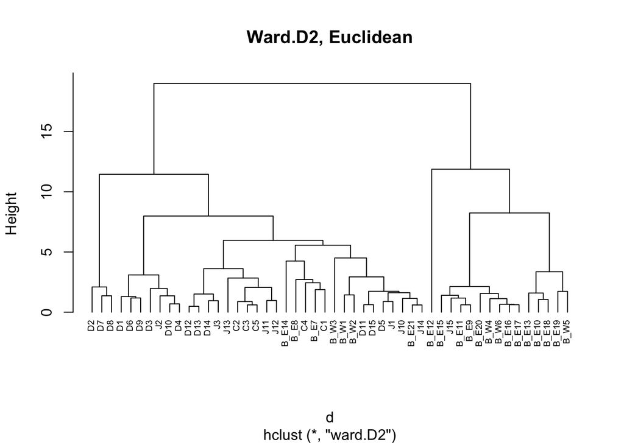

```r
#Ward
hc4 <- hclust(d, method = "ward.D2")

plot(hc4, labels = clusdat$point, hang = -1,
     main = "Ward.D2, Euclidean", cex = 0.6)
```

Note: The Ward plot showed clear and immediate branching in two directions, but the Manhattan plot was more gradual with fewer obvious breaks. The Ward plot seems more straightforward for interpretation.

Looking at how to break things up:

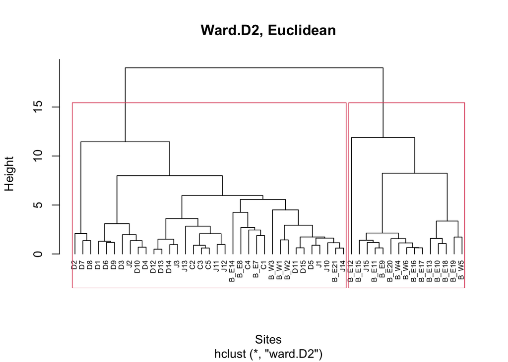

```r
# Ward dendrogram into 2
plot(hc4, labels = clusdat$point, hang = -1,
     main = "Ward.D2, Euclidean",
     xlab = "Sites", ylab = "Height", cex = 0.6)

# Then add rectangles for 2 clusters
rect.hclust(hc4, k = 2, border = 2)
```

and then 3 clusters for Ward:

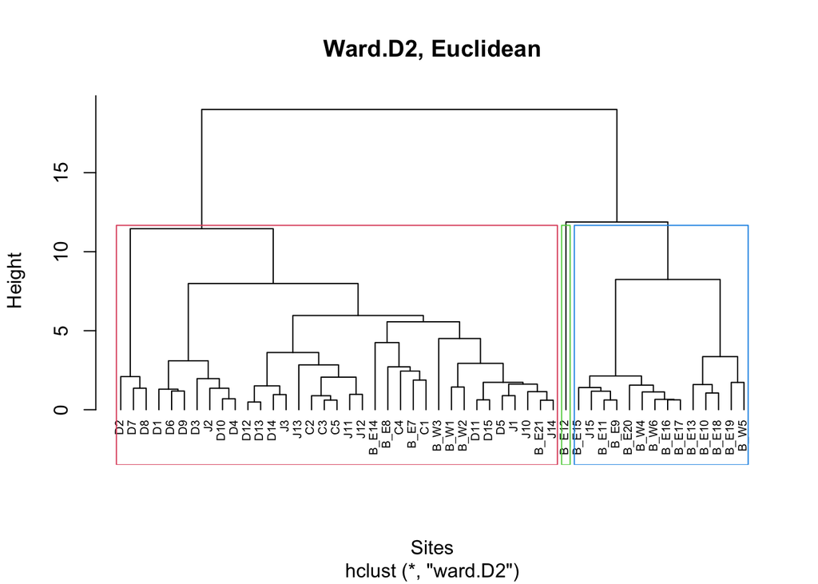

```r
plot(hc4, labels = clusdat$point, hang = -1,
     main = "Ward.D2, Euclidean",
     xlab = "Sites", ylab = "Height", cex = 0.6)

rect.hclust(hc4, k = 3, border = 2:4)
```

Now for Manhattan

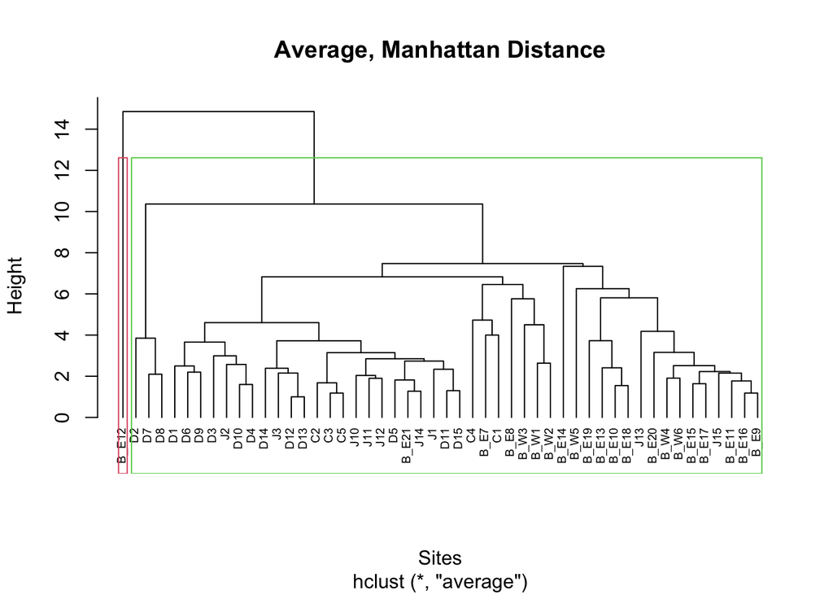

```r
plot(hc5, labels = clusdat$point, hang = -1,
     main = "Average, Manhattan Distance",
     xlab = "Sites", ylab = "Height", cex = 0.6)

rect.hclust(hc5, k = 2, border = 2:4)
```

and now Manhattan into 3 clusters:

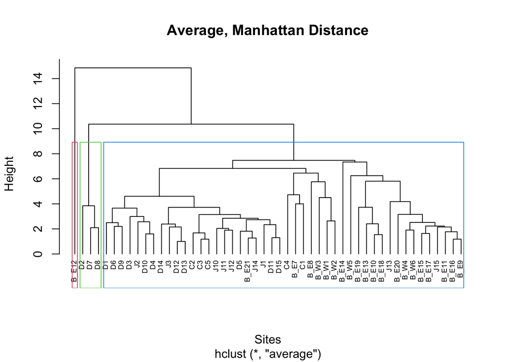

```r
plot(hc5, labels = clusdat$point, hang = -1,
     main = "Average, Manhattan Distance",
     xlab = "Sites", ylab = "Height", cex = 0.6)

rect.hclust(hc5, k = 3, border = 2:4)
```

Again, it seems that Ward’s method is better for interpretation. Both have one small branch, but otherwise Ward makes a cleaner and more balanced clustering. We’ll go with Ward’s.

**QUESTION 1.0**: Show the tree dendrogram for each of the four alternative hierarchical clustering analysis (i.e., hc1 to hc3, plus hc4 that you just added in). These will be very large; you may want to adjust the layout for each figure. Remember to include a figure caption at the bottom of each of the four figures (e.g., Figure 1. Euclidean distance and nearest neighbour clustering).

Notes: - hc1: Complete linkage clustering using Euclidean distance - hc2: Single linkage (nearest neighbour) clustering using Euclidean distance - hc3: Complete linkage clustering using Euclidean distance with standardized bird abundance variables - hc4: Ward’s hierarchical clustering using Euclidean distance

# *Important note: while the plots below use k=3 to divide breaks for visual clarity (which we used to help compare plots), this should not imply that all dendrograms truly display 3 clusters.*

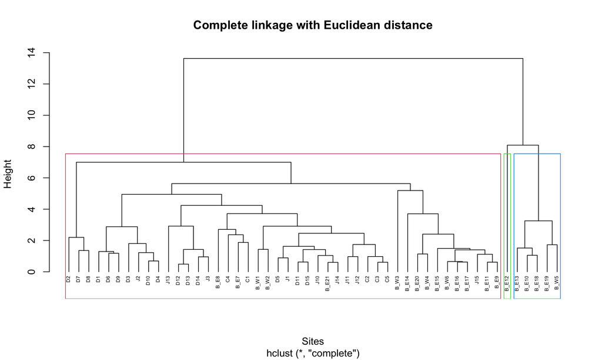

Figure 1. Tree dendrogram for hc1 using complete linkage with Euclidean distance, showing a 3-cluster cut.

```r
plot(hc1, labels = clusdat$point, hang = -1,
     main = "Complete linkage with Euclidean distance",
     xlab = "Sites", ylab = "Height", cex = 0.5)

rect.hclust(hc1, k = 3, border = 2:4)
```

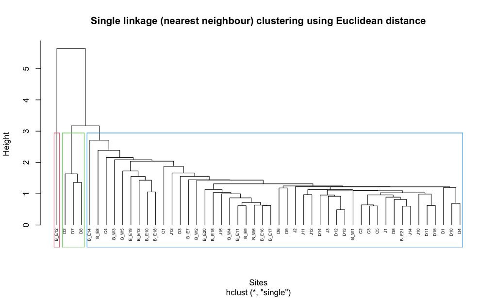

Figure 2. Tree dendrogram for hc2 using single linkage (nearest neighbor) with Euclidean distance, showing a 3-cluster cut.

```r
plot(hc2, labels = clusdat$point, hang = -1,
     main = "Single linkage (nearest neighbour) clustering using Euclidean distance",
     xlab = "Sites", ylab = "Height", cex = 0.5)

rect.hclust(hc2, k = 3, border = 2:4)
```

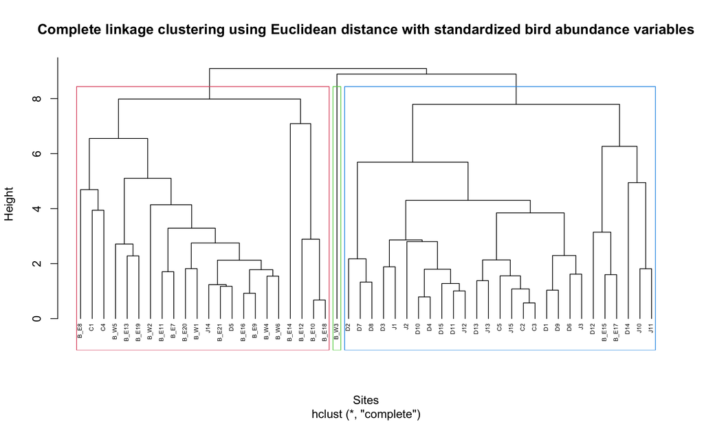

Figure 3. Tree dendrogram for hc3 using complete linkage with Euclidean distance on standardized bird abundance variables, showing a 3-cluster cut.

```r
plot(hc3, labels = clusdat$point, hang = -1,
     main = "Complete linkage clustering using Euclidean distance with standardized bird abundance variables",
     xlab = "Sites", ylab = "Height", cex = 0.5)

rect.hclust(hc3, k = 3, border = 2:4)
```